# Homework 3

Jacob Rosenthal

Due: Wednesday, December 5

```r
library(qqman)
library(data.table)
library(R.utils)
library(ggplot2)
library(knitr)
```

## Introduction

> In the last homework, we plotted summary statistics for LDL using a large cohort. In this homework, we’ll perform several regression analyses to understand how we can generate summary statistics. Rather than use the large dataset from the last homework we’ll restrict our analysis to chromosome 10. You can find the simulated case-control data in the ‘genotype.txt.gz’, ‘legend.txt’, and ‘phenotype.txt’ files on the course website.

```r
# Load data
# gunzip("genotype.txt.gz")
geno <- fread("genotype.txt", header = F)
pheno <- fread("phenotype.txt")
snp_pos <- fread("legend.txt")

lapply(list(geno, pheno, snp_pos), dim)
```

```
## [[1]]
## [1]  6081 34405
##
## [[2]]
## [1] 6081    3
##
## [[3]]
## [1] 34405     4
```

```r
# quality control: filter out rows and columns with >0.05 missing data
snpMissingRate <- colMeans(is.na(geno))
names(snpMissingRate) <- NULL
personMissingRate <- rowMeans(is.na(geno))

geno <- data.matrix(geno)
geno <- geno[which(personMissingRate <= 0.05), which(snpMissingRate <= 0.05)]
snp_pos <- snp_pos[which(snpMissingRate <= 0.05),]
pheno <- pheno[which(personMissingRate <= 0.05),]

lapply(list(geno, pheno, snp_pos), dim)
```

```
## [[1]]
## [1]  6013 34061
##
## [[2]]
## [1] 6013    3
##
## [[3]]
## [1] 34061     4
```

Quality control is performed to remove unreliable SNPs and individuals. In this case, we use a cutoff of 0.05. If a SNP is marked as NA for more than 5% of individuals, then we toss out that SNP. Likewise, if an individual has NA for more than 5% of SNPs, we toss out that individual from our data. After quality control, we filter out 344 SNPs and 68 individuals.

We also need to perform normalization/standardization of genotype data:

```r
for (j in 1:dim(geno)[2]) {
  temp <- geno[,j]
  geno[,j][is.na(temp)] <- median(temp,na.rm = TRUE)  #replace missing with median
  geno[,j] <- (geno[,j]-mean(geno[,j]))/sd(geno[,j])   #normalization / standarization
}
```

PCA

```r
PC <- prcomp(t(geno))
```

```r
allDF <- data.frame(ancestry = pheno$ancestry, gender = pheno$gender,
                    Y = pheno$Y, PC$rotation[,1:4])
```

## Problem 1

### Part A)

> Measure the association between each SNP and LDL status without adjusting for any other covariates. Note that $Y=1$ denotes having a high level of LDL (the bad kind of cholesterol).

```r
result <- snp_pos
result$noadjp <- 0

for (j in 1:dim(geno)[2]) {
  # model with no covariates
  noadj.mod <- summary(glm(allDF$Y~geno[,j], family=binomial()))$coeff
  # Overwrite the results data frame
  result[j,"noadjp"] <- noadj.mod[2,4]
}
```

### Part B)

> Include a qq-plot and Manhattan plot as we did in Homework 2 using the `qqman` package.

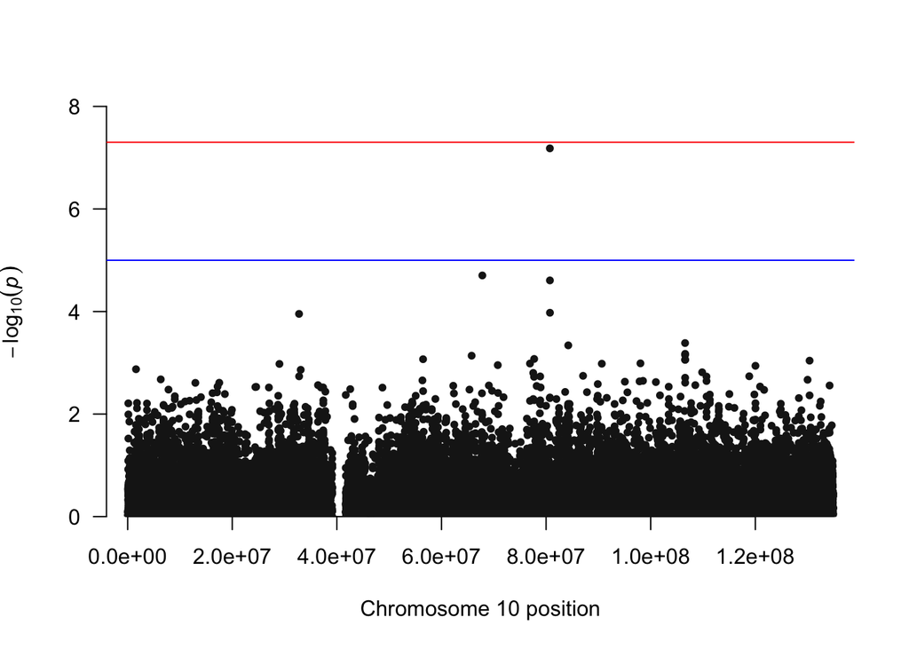

```r
manhattan(result, chr = "chr", bp = "position", p = "noadjp")
```

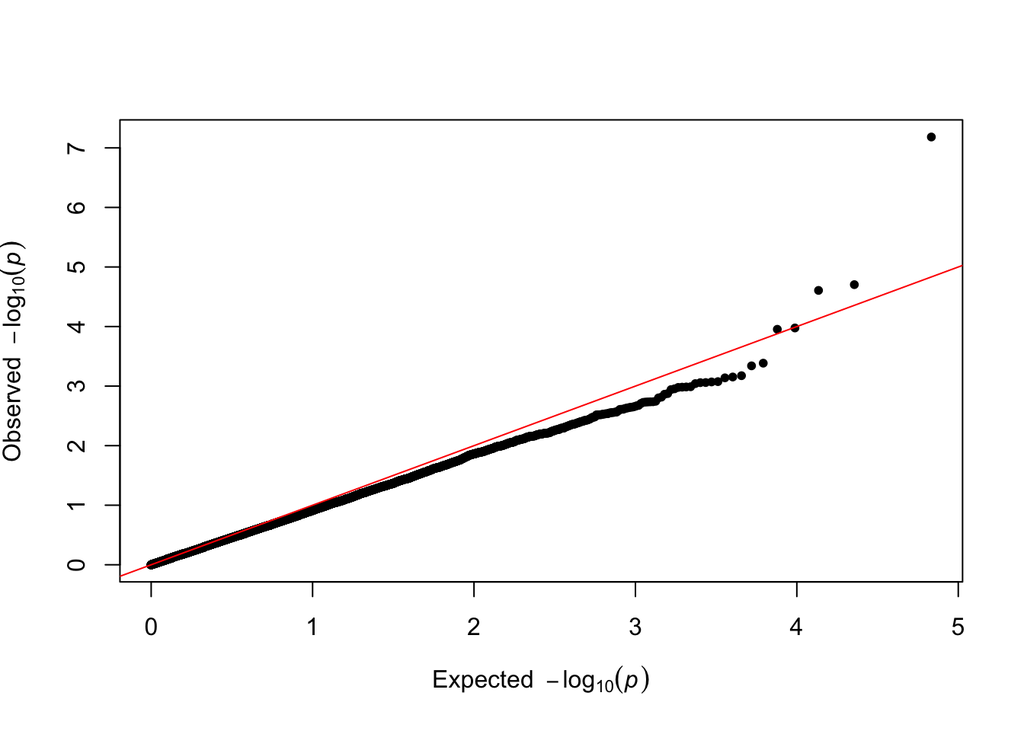

```r
qq(result$noadjp)
```

### Part C)

> Compute $\lambda_{GC}$ as we did in Homework 2. What does the computed value of $\lambda_{GC}$ say about the degree of inflation for this chromosome?

```r
qchisq(median(result$noadjp), df = 1, lower.tail=FALSE)/qchisq(0.5, df=1, lower.tail = FALSE)
```

```
## [1] 0.8516426
```

The inflation factor $\lambda_{GC} < 1$, meaning that inflation is not a concern in this case.

## Problem 2

### Part A)

> Rerun the analysis now adjusting for self-reported ancestry and sex.

```r
result$anc_sex_p <- 0
for (j in 1:dim(geno)[2]) {
  # model adjusting for sex and ancestry
  anc_sex.mod <- summary(glm(allDF$Y ~ geno[,j] + allDF$gender + allDF$ancestry,
                             family=binomial()))$coeff
  # Overwrite the results data frame
  result[j,"anc_sex_p"] <- anc_sex.mod[2,4]
}
```

### Part B)

> Rerun the analysis now adjusting for the first four principal components rather than using self-reported ancestry. Continue to include sex as a covariate in the model.

```r
result$PCp <- 0
for (j in 1:dim(geno)[2]) {
  # model adjusting for sex and PC 1 thru 4
  PC.mod <- summary(glm(allDF$Y ~ geno[,j] + allDF$gender + allDF$PC1 + allDF$PC2 + allDF$PC3 + allDF$PC4, family=binomial()))$coeff
  # Overwrite the results data frame
  result[j,"PCp"] <- PC.mod[2,4]
}

head(result)
```

```
##    chr position X0 X1    noadjp anc_sex_p       PCp
## 1:  10    26765  C  T 0.8108090 0.7599185 0.7500098
## 2:  10    65955  A  G 0.9422447 0.9761984 0.9640645
## 3:  10    67224  T  C 0.2888004 0.3432830 0.3483865
## 4:  10    67934  A  C 0.9341859 0.8846449 0.8878590
## 5:  10    81636  C  G 0.4715417 0.4670654 0.4597692
## 6:  10    88767  A  G 0.7503522 0.8325495 0.8469406
```

### Part C)

> Summarize the results at a per-SNP level using a scatterplot where each point on the scatterplot represents a single SNP. Plot the $-\log_{10}(p)$ for each SNP from 2A on the x-axis and the $-\log_{10}(p)$ for each SNP from 2B on the y-axis. What would the scatterplot look like if adjusting for self-reported ancestry were equivalent to adjusting for the first four principal components?

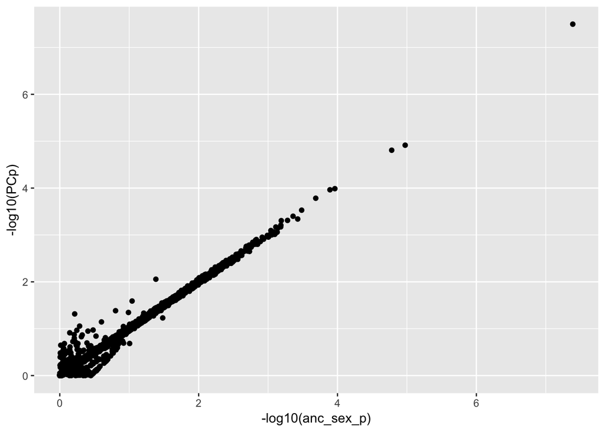

```r
ggplot(result, aes(x = -log10(anc_sex_p), y = -log10(PCp))) +
  geom_point()
```

If adjusting for self-reported ancestry were exactly the same as adjusting for the first four principal components, then the models would be identical. Each SNP would therefore have the same p-value in both models, so every point in the scatterplot would lie on the y=x line. We see that this plot does follow this trend as most of the points lie on that line, although not perfectly.

## Problem 3

> Using the summary statistics for the unadjusted associations that you calculated in Problem 1 and either model (your choice) from Problem 2, plot the region $\pm$ 100,000 bp around the top SNP discovered from your adjusted model using Locuszoom. Include the plots in your submission as part of a single document.

```r
dfout_unadjusted <- data.frame(MarkerName = paste0("chr", result$chr, ":", result$position), P.value = result$noadjp)

write.table(dfout_unadjusted, file = "LocusZoom_unadjusted.csv",
            sep = ",", row.names = FALSE, col.names = TRUE, quote = FALSE)

min_p_pos_unadjusted <- result$position[which.min(result$noadjp)]

dfout_PC <- data.frame(MarkerName = paste0("chr", result$chr, ":",
                                           result$position), P.value = result$PCp)

write.table(dfout_PC, file = "LocusZoom_PC.csv", sep = ",",
            row.names = FALSE, col.names = TRUE, quote = FALSE)

min_p_pos_PC <- result$position[which.min(result$PCp)]

min_p_pos_unadjusted
```

```
## [1] 80720532
```

```r
min_p_pos_PC
```

```
## [1] 80720532
```

Both models (unadjusted and adjusting for the first four principal components) find the same SNP being the most significant. It is located at 80720532. So for this LocusZoom plot, we want to show the region between 80.62Mb and 80.82Mb. (See below)

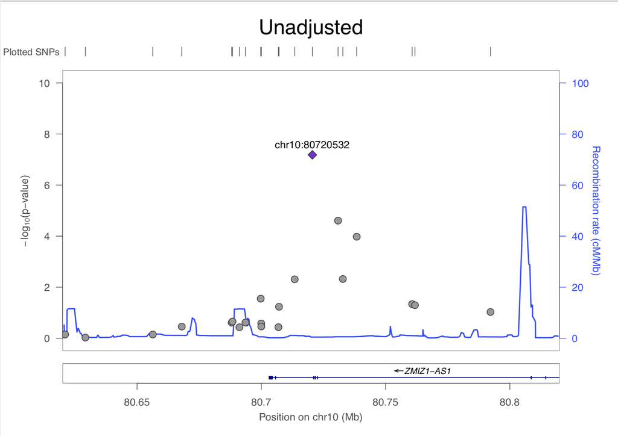

```r
include_graphics("unadjusted_locuszoom_plot.png")
```

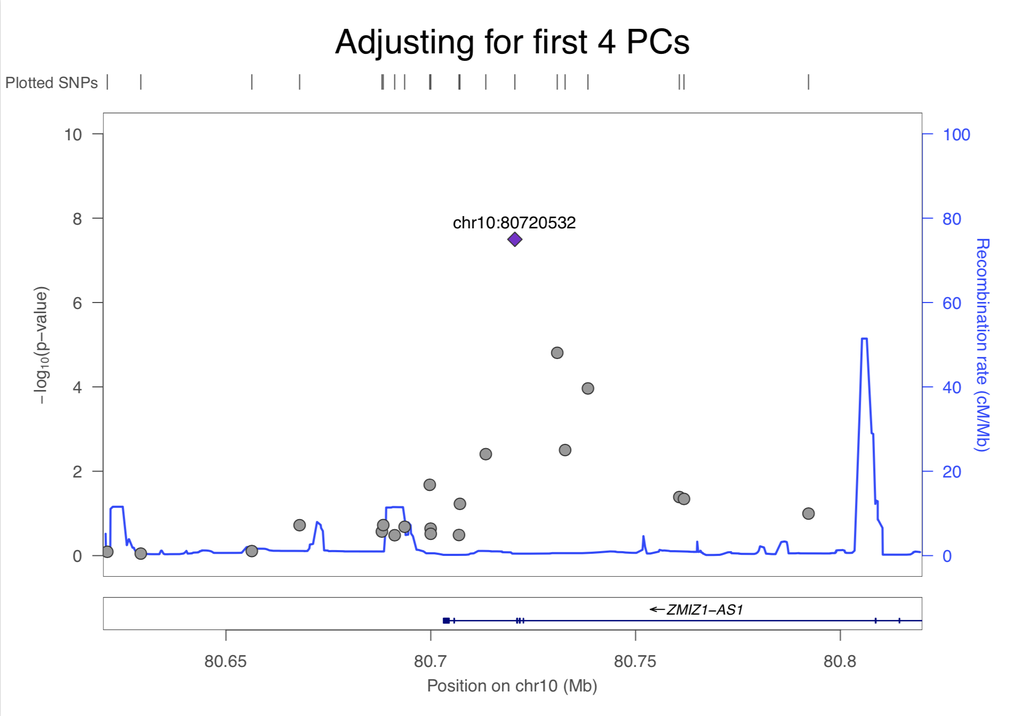

```r
include_graphics("PCadj_locuszoom_plot.png")
```

In this case, the plots look very similar. It is almost impossible to tell the difference just by looking at them.